# Introduction

The goal of this analysis is to help an app developer better understand the app market. Specific questions asked here are: How does size of an app affect its user ratings? Does an app's price affect its popularity? How do these responses change between google and apple users?

Data sets for this analysis was obtained from [Kaggle](https://www.kaggle.com/). Data for google playstore is available [here](https://www.kaggle.com/lava18/google-play-store-apps/home) and that for apple app store is available [here](https://www.kaggle.com/ramamet4/app-store-apple-data-set-10k-apps/home)

## Data reading and preparation

First, read the data files and look at the columns

```python
# Read *.csv files
import pandas as pd
df_android = pd.read_csv("googleplaystore.csv")
df_apple = pd.read_csv("AppleStore.csv")
```

```python
# Look at the android data
df_android.head()
```

|  | App | Category | Rating | Reviews | Size | Installs | Type | Price | Content Rating | Genres | Last Updated | Current Ver | Android Ver |
| --- | --- | --- | --- | --- | --- | --- | --- | --- | --- | --- | --- | --- | --- |
| 0 | Photo Editor & Candy Camera & Grid & ScrapBook | ART_AND_DESIGN | 4.1 | 159 | 19M | 10,000+ | Free | 0 | Everyone | Art & Design | January 7, 2018 | 1.0.0 | 4.0.3 and up |
| 1 | Coloring book moana | ART_AND_DESIGN | 3.9 | 967 | 14M | 500,000+ | Free | 0 | Everyone | Art & Design;Pretend Play | January 15, 2018 | 2.0.0 | 4.0.3 and up |
| 2 | U Launcher Lite – FREE Live Cool Themes, Hide ... | ART_AND_DESIGN | 4.7 | 87510 | 8.7M | 5,000,000+ | Free | 0 | Everyone | Art & Design | August 1, 2018 | 1.2.4 | 4.0.3 and up |
| 3 | Sketch - Draw & Paint | ART_AND_DESIGN | 4.5 | 215644 | 25M | 50,000,000+ | Free | 0 | Teen | Art & Design | June 8, 2018 | Varies with device | 4.2 and up |
| 4 | Pixel Draw - Number Art Coloring Book | ART_AND_DESIGN | 4.3 | 967 | 2.8M | 100,000+ | Free | 0 | Everyone | Art & Design;Creativity | June 20, 2018 | 1.1 | 4.4 and up |

There are two things that need to be fixed. One, prices in the Android data set has '$' sign before the numbers. This has to be removed in order to convert the variable type into float. And second, the alphabets 'M' and 'k' have been used to denote megabytes and kilobytes respectively for app size. These need to be converted into bytes.

```python
# First fix the price issue
temp = df_android['Price'].str.replace('$', '')
temp2 = pd.to_numeric(temp, errors=coerce)
df_android['price'] = temp2
```

```python
# Then deal with the sizes
# First look at what the last characters are in the size column
lastChars = df_android['Size'].str.slice(-1)
print pd.unique(lastChars)
```

```
['M' 'e' 'k' '+']
```

```python
# What is 'e' and '+'?
# First let us look at the '+'
df_android[df_android['Size'].str.endswith('+')]
```

|  | App | Category | Rating | Reviews | Size | Installs | Type | Price | Content Rating | Genres | Last Updated | Current Ver | Android Ver | price |
| --- | --- | --- | --- | --- | --- | --- | --- | --- | --- | --- | --- | --- | --- | --- |
| 10472 | Life Made WI-Fi Touchscreen Photo Frame | 1.9 | 19.0 | 3.0M | 1,000+ | Free | 0 | Everyone | NaN | February 11, 2018 | 1.0.19 | 4.0 and up | NaN | NaN |

Looks like this entry has problems. Values are shifted to the left by one column. But for now, let us drop this entry.

```python
df_android.drop(10472, inplace=True)
df_android.reset_index(inplace=True)
```

```python
# Now what about that 'e'?
pd.unique(df_android[df_android['Size'].str.endswith('e')]['Size'])
```

```
array(['Varies with device'], dtype=object)
```

These entries will have to be ignored for quantitative analysis.

Now, the final part. Dropping "M" and "k", and multiplying each with the relevant conversion factor.

```python
import numpy as np

# create array of -1.0 (size cannot be -1, so this is sort of a control)
size_bytes = -1.0 * np.ones(df_android.shape[0])
# now fill it up
megabytes = df_android['Size'][df_android['Size'].str.endswith('M')]
kilobytes = df_android['Size'][df_android['Size'].str.endswith('k')]

# verify how many were not filled
print "Number of non-quantitative sizes: ", sum(size_bytes == -1.0)
# these were the version-dependent sizes.

# now use regular expression to convert "3.0M" to "3.0"
megabytes_num = megabytes.str.findall('\d+(?:\.\d+)?')
# but, if some entries had problems, there will be more than one value.
# check that (expecting 1)
lengths = megabytes.str.findall('\d+(?:\.\d+)?').str.len()
print np.max(lengths)

# now do the conversion
for i in range(megabytes_num.shape[0]):
    size_bytes[megabytes.index[i]] = float(megabytes_num.iloc[i][0]) * 1024 * 1024

# now do the same for kilobytes
kilobytes_num = kilobytes.str.findall('\d+(?:\.\d+)?')
lengths = kilobytes.str.findall('\d+(?:\.\d+)?').str.len()
# expecting 1
print np.max(lengths)

for i in range(kilobytes_num.shape[0]):
    size_bytes[kilobytes.index[i]] = float(kilobytes_num.iloc[i][0]) * 1024

# add extra column 'size_bytes'
df_android['size_bytes'] = size_bytes
```

```
Number of non-quantitative sizes:  10840
1
1
```

```python
# Now look at the apple data
df_apple.head()
```

|  | Unnamed: 0 | id | track_name | size_bytes | currency | price | rating_count_tot | rating_count_ver | user_rating | user_rating_ver | ver | cont_rating | prime_genre | sup_devices.num | ipadSc_urls.num | lang.num | vpp_lic |
| --- | --- | --- | --- | --- | --- | --- | --- | --- | --- | --- | --- | --- | --- | --- | --- | --- | --- |
| 0 | 1 | 281656475 | PAC-MAN Premium | 100788224 | USD | 3.99 | 21292 | 26 | 4.0 | 4.5 | 6.3.5 | 4+ | Games | 38 | 5 | 10 | 1 |
| 1 | 2 | 281796108 | Evernote - stay organized | 158578688 | USD | 0.00 | 161065 | 26 | 4.0 | 3.5 | 8.2.2 | 4+ | Productivity | 37 | 5 | 23 | 1 |
| 2 | 3 | 281940292 | WeatherBug - Local Weather, Radar, Maps, Alerts | 100524032 | USD | 0.00 | 188583 | 2822 | 3.5 | 4.5 | 5.0.0 | 4+ | Weather | 37 | 5 | 3 | 1 |
| 3 | 4 | 282614216 | eBay: Best App to Buy, Sell, Save! Online Shop... | 128512000 | USD | 0.00 | 262241 | 649 | 4.0 | 4.5 | 5.10.0 | 12+ | Shopping | 37 | 5 | 9 | 1 |
| 4 | 5 | 282935706 | Bible | 92774400 | USD | 0.00 | 985920 | 5320 | 4.5 | 5.0 | 7.5.1 | 4+ | Reference | 37 | 5 | 45 | 1 |

One thing needs to be changed here. Unlike the Android data set, this one does not have a column ("Type") that denotes whether or not a given app is paid. This column needs to be created.

```python
# create array of zeros
test = np.zeros(df_apple.shape[0])
# if price is 0 (app is free), change value to 1
test[df_apple['price'] == 0] = 1
test2 = {0: 'Paid', 1: 'Free'}
# now map "1" to "Free", and "0" to "Paid"
test3 = pd.Series(test).map(test2)
df_apple['Type'] = test3
```

Now one final thing in preparation. Data type for the Android data set is "object" for most of the quantitative columns. These need to be changed to "float". For the time being, this will be done just for the "Reviews" column as it will be used later.

```python
df_android['Reviews'] = df_android['Reviews'].astype(float)
```

## Exploratory analysis

[figure not shown]

```python
# First, look at the different categories of app in the two data sets

# Changing the category names format so they are similar in both data sets.
df_android['Category'] = df_android['Category'].str.title().str.replace('_', ' ')
df_apple['prime_genre'] = df_apple['prime_genre'].str.replace('&','and')

import matplotlib.pyplot as plt
fig, ax = plt.subplots(1,2)
fig.set_figheight(10)
fig.set_figwidth(20)
#df_android.groupby(by='Category').size().plot.pie(rotatelabels=True, fontsize=14)
#df_apple.groupby(by='prime_genre').size().plot.pie(rotatelabels=True, fontsize=14, startangle=-10)
df_android.groupby(by='Category').size().plot.bar(ax=ax[0])
df_apple.groupby(by='prime_genre').size().plot.bar(ax=ax[1])
ax[0].set_xlabel('')
ax[1].set_xlabel('')
ax[0].set_ylabel('')
ax[1].set_ylabel('')
ax[0].text(0, 1800, "Android", fontsize=24)
ax[1].text(0, 3500, "Apple", fontsize=24)
ax[0].set_ylabel("Number of apps in said category")
plt.show()
```

This is an interesting observation. More than 50% of all the apps in the Apple app store are games.

### What proportion of the apps are paid?

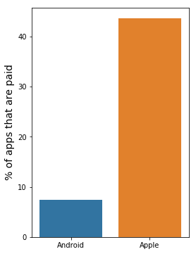

```python
# Now let see what percentage of each app store apps are free
import seaborn as sns
perc_android_notFree = sum(df_android['Type']== "Paid") * 100./df_android.shape[0]
perc_apple_notFree = sum(df_apple['Type'] == "Paid") * 100./df_apple.shape[0]
barDat = [perc_android_notFree, perc_apple_notFree]
plt.figure(figsize=(4,6))
sns.barplot(x=np.array([0,1]), y=barDat)
plt.gca().set_xticklabels(['Android', 'Apple'])
plt.ylabel("% of apps that are paid", fontsize=14)
plt.show()
```

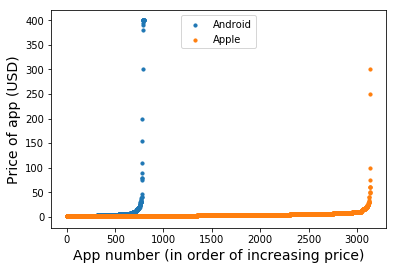

```python
# How expensive are the paid apps?
android_prices = df_android[df_android['price'] > 0]['price']
apple_prices = df_apple[df_apple['price'] > 0]['price']
plt.scatter(range(android_prices.shape[0]), android_prices.sort_values(), s=10, label='Android')
plt.scatter(range(apple_prices.shape[0]), apple_prices.sort_values(), s=10, label='Apple')
plt.legend(loc=9)
plt.xlabel("App number (in order of increasing price)", fontsize=14)
plt.ylabel("Price of app (USD)", fontsize=14)
plt.show()
```

Here is another interesting observation. While a larger share of Apple's apps are paid, Android's paid apps are actually more expensive than those of Android's.

### Comparison of app sizes

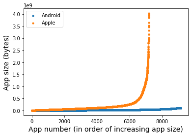

```python
# Now let us look at the app-size distribution.
# Note that for Android data, some sizes are in negatives.
df_realsizes = df_android['size_bytes'][df_android['size_bytes'] >= 0]
plt.scatter(range(df_realsizes.shape[0]), df_realsizes.sort_values(), s=10, label='Android')
plt.scatter(range(df_apple['size_bytes'].shape[0]), df_apple['size_bytes'].sort_values(), s=10, label='Apple')
plt.legend()
plt.xlabel("App number (in order of increasing app size)", fontsize=14)
plt.ylabel("App size (bytes)", fontsize=14)
plt.show()
```

Next, look at the differences between paid and free apps. For this, consider the ratings and popularity. Popularity can be best judged by number of installs. This data is available for Android, not for apple. Thus, to keep things consistent, number of reviews will be used as the metric for how many people are using a given app.

### User response to free vs. paid apps

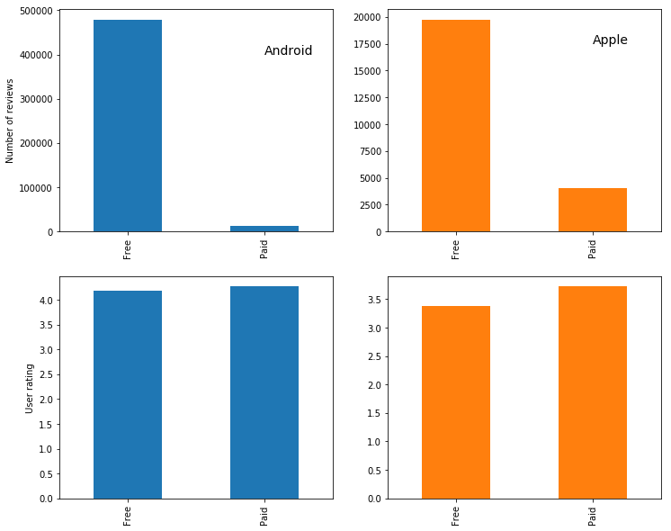

```python
fig, ax = plt.subplots(2,2)
fig.set_figwidth(12)
fig.set_figheight(10)
df_android.groupby(by='Type').Reviews.mean().plot.bar(ax=ax[0][0])
df_apple.groupby(by='Type').rating_count_tot.mean().plot.bar(ax=ax[0][1], color='#ff7f0e')
df_android.groupby(by='Type').Rating.mean().plot.bar(ax=ax[1][0])
df_apple.groupby(by='Type').user_rating.mean().plot.bar(ax=ax[1][1], color='#ff7f0e')
ax[0][0].set_xlabel('')
ax[0][1].set_xlabel('')
#ax[0][0].set_xticklabels([])
#ax[0][1].set_xticklabels([])
ax[1][0].set_xlabel('')
ax[1][1].set_xlabel('')
ax[0][0].set_ylabel('Number of reviews')
ax[1][0].set_ylabel('User rating')
ax[0][0].text(1,400000, 'Android', fontsize=14)
ax[0][1].text(1,17500, 'Apple', fontsize=14)
plt.show()
```

However, looking at the user rating, the two categories of apps fare almost similarly for both the data sets. Thus, **user satisfaction is independent of app price provided the user decides to use it**.